# Final Project MICR150

## Did the normalization work?

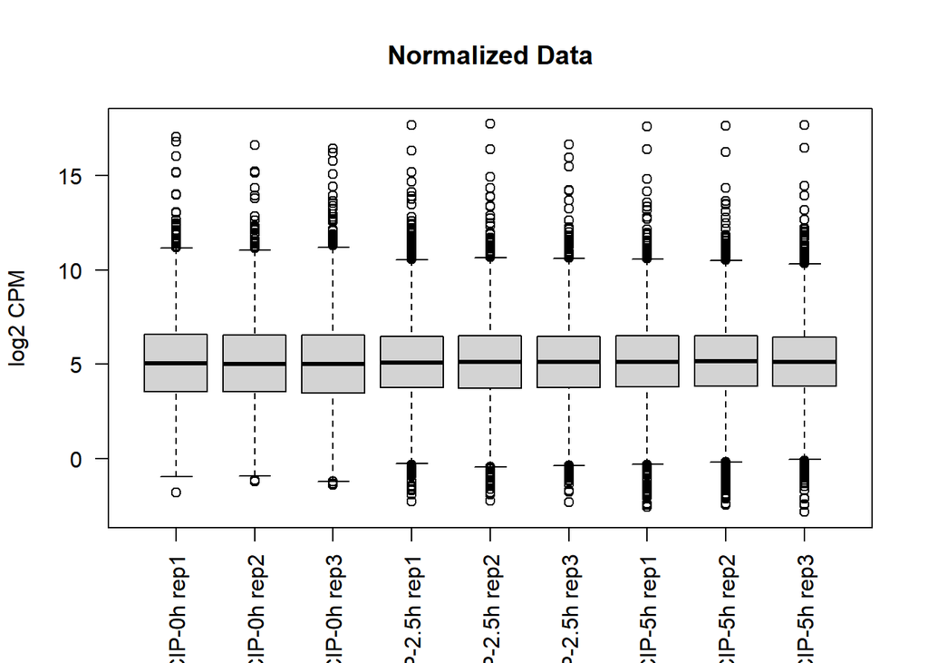

```r
# Generate normalized log2 transformed CPMs:
CPM <- cpm(DGE, normalized.lib.sizes = TRUE, log = TRUE)
CPM <- as.data.frame(CPM)

# Visualize normalized data
boxplot(CPM, las = 2, ylab = "log2 CPM", main = "Normalized Data")
```

## GLM likelihood ratio test for identifying DE genes

The GLM likelihood ratio test is based on the idea of fitting negative binomial GLMs with the Cox-Reid dispersion estimates. This takes all known sources of variation into account. Therefore, the GLM likelihood ratio test is recommended for experiments with multiple factors.

## Fit a gene-wise negative binomial generalized linear model

```r
fit <- glmFit(DGE, design)
colnames(fit$coefficients)
```

```
## [1] "(Intercept)" "Sinfo$Code1" "Sinfo$Code2"
```

## Conduct likelihood ratio test to identify DE genes of PA treatment

```r
lrt1 <- glmLRT(fit, coef = "Sinfo$Code1") #specify the comparison of interest
topTags(lrt1)
```

```
## Coefficient:  Sinfo$Code1
##            logFC   logCPM       LR       PValue          FDR
## PA5355 -4.010444 7.840514 378.1213 3.191480e-84 1.774782e-80
## PA0446  3.628671 8.031958 278.2501 1.806882e-62 5.024036e-59
## PA2000  3.896703 8.277030 268.6900 2.189856e-60 4.059263e-57
## PA2323 -2.679490 5.365258 254.4316 2.807632e-57 3.903310e-54
## PA1566 -2.891559 4.927713 244.6473 3.814388e-55 4.076123e-52
## PA4659 -3.139989 5.645004 244.3638 4.397903e-55 4.076123e-52
## PA2166  3.320514 7.964811 233.8887 8.459023e-53 6.720090e-50
## PA4658 -3.039768 6.683393 227.1468 2.498000e-51 1.736422e-48
## PA2109  2.508579 4.832758 226.2490 3.920957e-51 2.422716e-48
## PA2112  2.935970 6.514519 219.5996 1.105924e-49 6.150042e-47
```

```r
lrt2 <- glmLRT(fit, coef = "Sinfo$Code2") #specify the comparison of interest
topTags(lrt2)
```

```
## Coefficient:  Sinfo$Code2
##            logFC   logCPM       LR        PValue           FDR
## PA5355 -5.475847 7.840514 603.1143 3.518990e-133 1.956910e-129
## PA1899  5.537496 4.091999 557.1385 3.524524e-123 9.799938e-120
## PA4211  5.813667 7.156027 405.4581  3.571039e-90  6.619516e-87
## PA1864  4.550751 4.754581 383.5481  2.101291e-85  2.921319e-82
## PA4210  3.841039 3.665843 347.7237  1.326876e-77  1.475752e-74
## PA5374 -4.164976 7.344267 340.5091  4.943153e-76  4.581479e-73
## PA0446  3.893411 8.031958 312.9089  5.076310e-70  4.032766e-67
## PA1902  5.113221 5.420382 309.9306  2.261174e-69  1.571798e-66
## PA5353 -3.653358 5.008720 301.4135  1.621102e-67  1.001661e-64
## PA4209  3.512722 6.279480 295.7275  2.809438e-66  1.562329e-63
```

## How many genes are up- or down-regulated by EV?

```r
de1 <- decideTestsDGE(lrt1, adjust.method = "fdr")
summary(de1)
```

```
##        Sinfo$Code1
## Down          1435
## NotSig        2459
## Up            1667
```

```r
de2 <- decideTestsDGE(lrt2, adjust.method = "fdr")
summary(de2)
```

```
##        Sinfo$Code2
## Down          1495
## NotSig        2340
## Up            1726
```

## Exporting the results

```r
Results1 <- as.data.frame(topTags(lrt1, n = dim(DGE)[1]))

write.csv(Results1, file = "edgeR_Results1.csv", row.names = TRUE)
Results2 <- as.data.frame(topTags(lrt2, n = dim(DGE)[1]))

write.csv(Results2, file = "edgeR_Results2.csv", row.names = TRUE)
```

## MA Plot with all DE genes in red

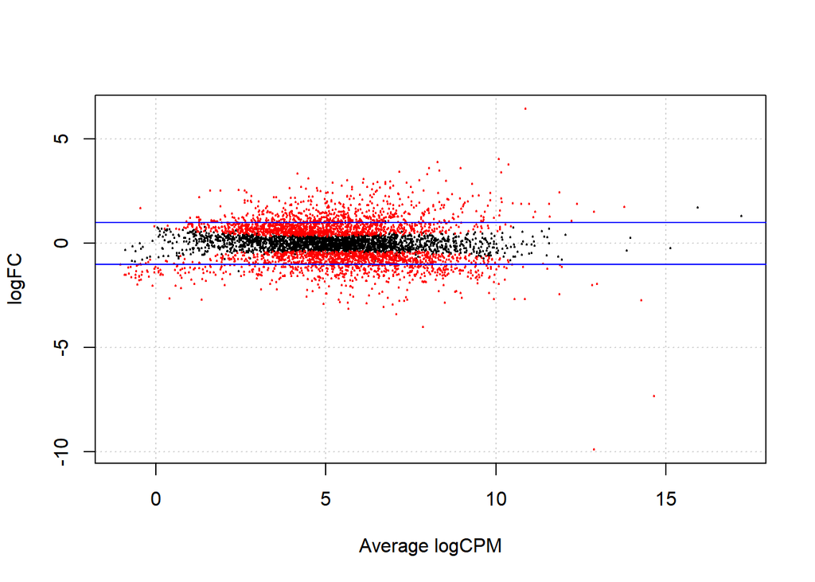

```r
detags1 <- rownames(DGE)[as.logical(de1)]
plotSmear(lrt1, de.tags = detags1)
abline(h = c(-1, 1), col = "blue")
```

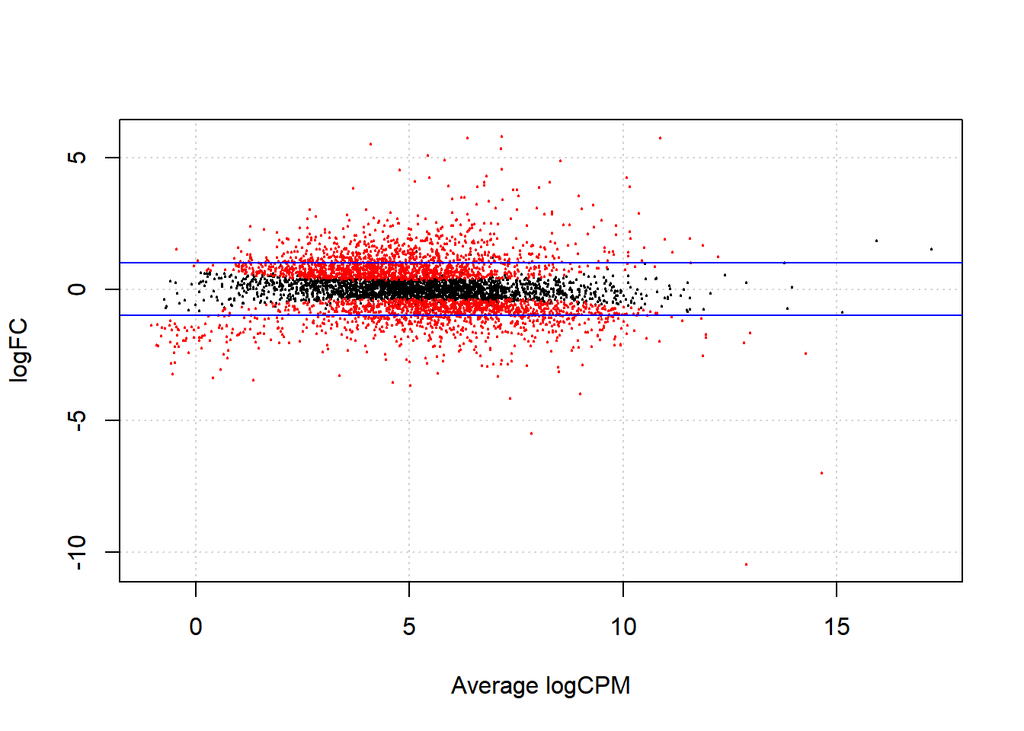

```r
detags2 <- rownames(DGE)[as.logical(de2)]
plotSmear(lrt2, de.tags = detags2)
abline(h = c(-1, 1), col = "blue")
```

## Selecting DE genes by fold change and p-value, rather than just FDR

#### Number of genes with p < 0.05 (uncorrected) and absolute log2FC > 1 (2-fold change):

```r
DE1 <- Results1[Results1$PValue < 0.05 & abs(Results1$logFC) > 1, ]
dim(DE1)[1]
```

```
## [1] 1078
```

```r
DE2 <- Results2[Results2$PValue < 0.05 & abs(Results2$logFC) > 1, ]
dim(DE2)[1]
```

```
## [1] 1227
```

## MA Plot with 1078 and 1227 DE genes in red

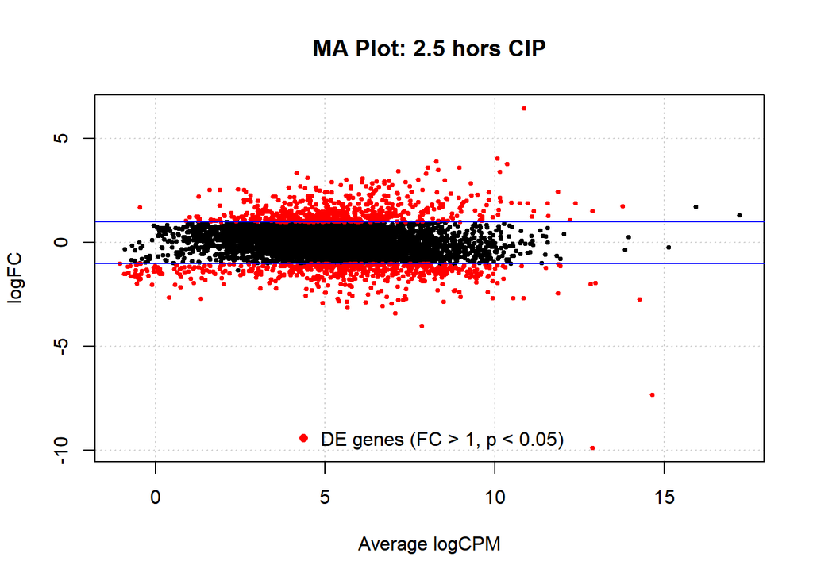

```r
detags3 <- rownames(DE1)

plotSmear(lrt1, de.tags = detags3, cex = 0.5, main = "MA Plot: 2.5 hors CIP")
abline(h = c(-1, 1), col = "blue")
legend("bottom", legend = "DE genes (FC > 1, p < 0.05)", pch = 16,
       col = "red", bty = "n")
```

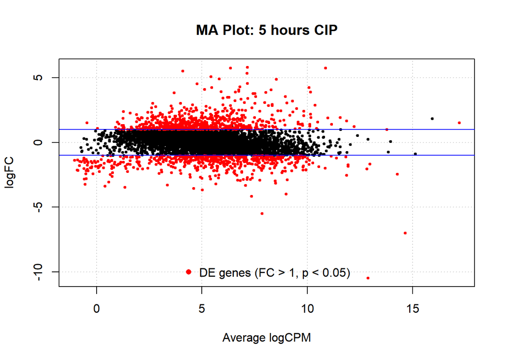

```r
detags4 <- rownames(DE2)
plotSmear(lrt2, de.tags = detags4, cex = 0.5, main = "MA Plot: 5 hours CIP")
abline(h = c(-1, 1), col = "blue")
legend("bottom", legend = "DE genes (FC > 1, p < 0.05)", pch = 16,
       col = "red", bty = "n")
```

## Volcano plot with 1078 and 1227 DE genes in red

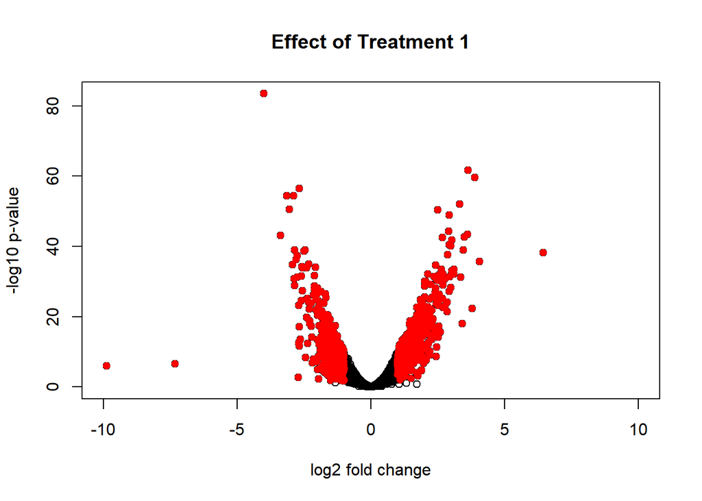

```r
detags5<- DE1$PValue
plot(-log10(Results1$PValue) ~ Results1$logFC,
     xlab = "log2 fold change", ylab = "-log10 p-value",
     main = "Effect of Treatment 1", xlim = c(-10, 10))

points(-log10(Results1$PValue[Results1$PValue %in% detags5]) ~
        Results1$logFC[Results1$PValue %in% detags5],
        col = "red", pch = 16)
```

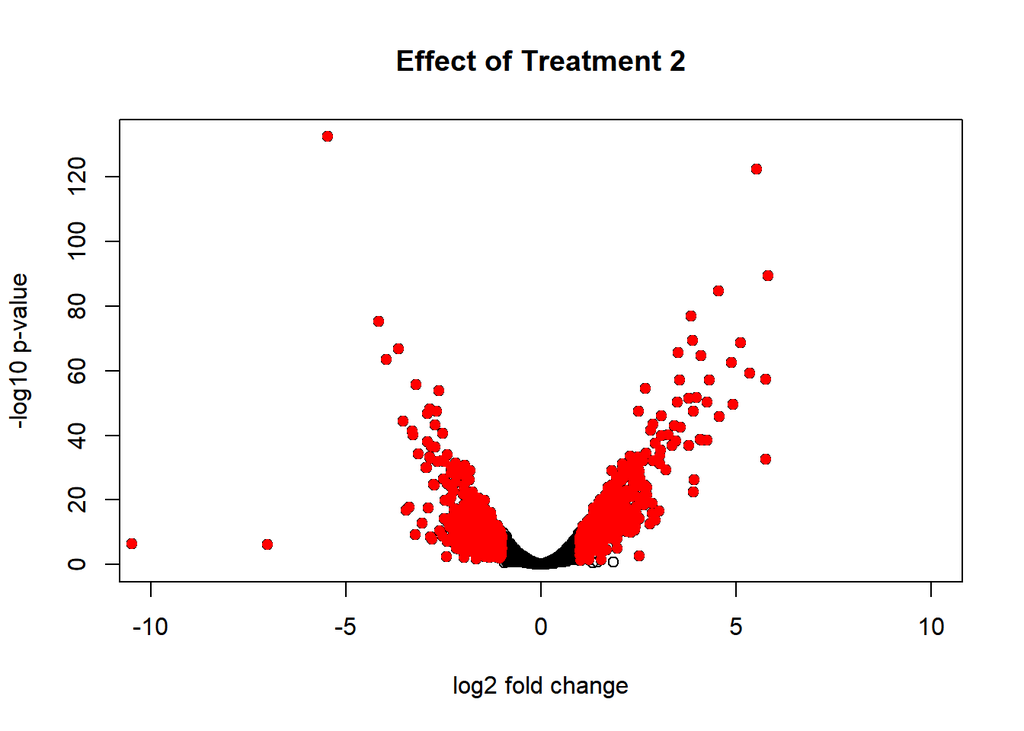

```r
detags6<- DE2$PValue
plot(-log10(Results2$PValue) ~ Results2$logFC,
     xlab = "log2 fold change", ylab = "-log10 p-value",
     main = "Effect of Treatment 2", xlim = c(-10, 10))

points(-log10(Results2$PValue[Results2$PValue %in% detags6]) ~
        Results2$logFC[Results2$PValue %in% detags6],
        col = "red", pch = 16)
```

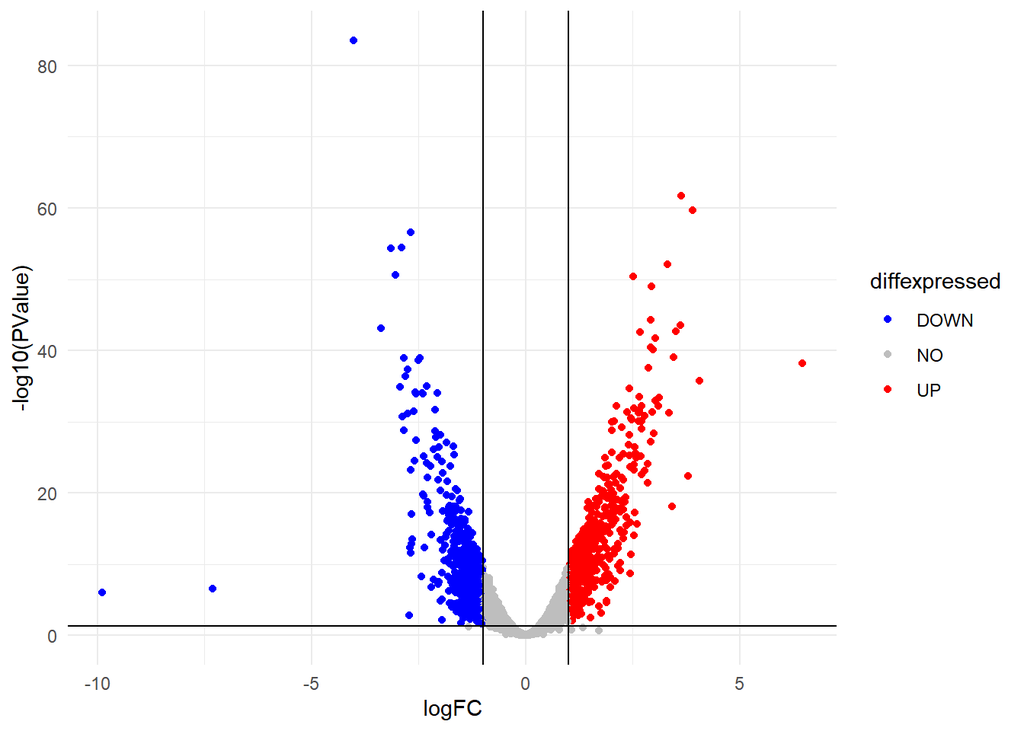

```r
Results1$diffexpressed <- "NO"
Results1$diffexpressed[Results1$logFC > 1 & Results1$PValue < 0.05] <- "UP"
Results1$diffexpressed[Results1$logFC < -1 & Results1$PValue < 0.05] <- "DOWN"

Results1$delabel <- NA

ggplot(data=Results1, aes(x=logFC, y=-log10(PValue), col=diffexpressed, label=diffexpressed)) + geom_point() + theme_minimal() + geom_vline(xintercept=c(-1, 1), col="black") + geom_hline(yintercept=-log10(0.05), col="black") + scale_color_manual(values=c("blue", "gray", "red"))
```